# Week 15 Homework TidyTuesday 5 - Learning how to customize quarto theme

Author

Leah Barkai

Published

December 8, 2025

## Introduction

This document presents my Week 15 homework, using [Can an exploding snowman predict the summer season?](https://github.com/rfordatascience/tidytuesday/blob/main/data/2025/2025-12-02/readme.md#can-an-exploding-snowman-predict-the-summer-season) dataset from TidyTuesday. The dataset measures the burn duration of the Böögg effigy and various climate variables in Zurich, Switzerland, dating back to 1900.

I also made the data dictionary more presentable than what was provided on TidyTuesday.

## Load Libraries

The following R libraries were used for this TidyTuesday assignment.

```r
library(tidyverse)     # Loads core R packages for data handling and plotting
library(kableExtra)    # Needed for styling the HTML table/data dictionary
library(tidyr)         # Helps with tidying/reshaping data
library(here)          # Constructs file paths reliably
```

## Read in data

This data was from TidyTuesday’s [Can an exploding snowman predict the summer season?](https://github.com/rfordatascience/tidytuesday/blob/main/data/2025/2025-12-02/readme.md#can-an-exploding-snowman-predict-the-summer-season) dataset.

```r
sechselaeuten <- readr::read_csv('https://raw.githubusercontent.com/rfordatascience/tidytuesday/main/data/2025/2025-12-02/sechselaeuten.csv')
```

## Data Dictionary

This data dictionary is available on [TidyTuesday](https://github.com/rfordatascience/tidytuesday/blob/main/data/2025/2025-12-02/readme.md#sechselaeutencsv) for the sechselaeuten data.

To make the data dictionary visually appealing, I used the **`kableExtra`** R package to transform the raw data into an elegant HTML table. I first created the dictionary data using `tribble()` and then piped it into **`knitr::kable()`** to render the HTML. Finally, I applied advanced styling using **`kable_styling()`** (adding features like **striped rows** and **hover effects**) and used **`row_spec()`** to visually highlight the key predictor variable, `duration`, with bold text and a light blue background.

| Variable | Data Dictionary: sechselaeuten.csv Type | Data Dictionary: sechselaeuten.csv Description |
| --- | --- | --- |
| year | double | Year of the Sechselaeuten festival. |
| duration | double | Time elapsed from ignition of Böögg effigy until explosion (in minutes). This is the key predictor variable. |
| tre200m0 | double | Average air temperature 2 m above ground (monthly mean in °C). |
| tre200mn | double | Minimum air temperature 2 m above ground (absolute monthly minimum in °C). |
| tre200mx | double | Maximum air temperature 2 m above ground (absolute monthly maximum in °C). |
| sre000m0 | double | Total sunshine duration (monthly total in hours). |
| sremaxmv | double | Total sunshine duration as a percentage of the possible maximum. |
| rre150m0 | double | Total precipitation (monthly total in mm). |
| record | logical | Years with average summer temperature above 19 °C. |

## Custom Quarto Styling with SCSS

I learned how to use **SCSS (Sass)** to customize Quarto’s built-in theme (`cosmo`). SCSS is a preprocessor scripting language that compiles into standard CSS, allowing for cleaner code and the use of variables.

I created a separate file named **`styles.scss`** and linked it in the YAML header (`theme: [cosmo, styles.scss]`).

Below is what I put in the styles.scss text:

```r
# /*-- scss:defaults --*/
# $primary: #4B0082; - this makes the primary color purple
# $font-family-sans-serif: 'Georgia', serif; - this is the font
# $link-color: $primary; - make hyperlinks use primary color
# $headings-color: $primary; - make headings use it too

# /*-- scss:rules --*/
# .quarto-title-block .quarto-title-banner { - picking a certain part of the theme
# background-color: #f0f8ff;} - puts background color of title
```

# Plot

Here I made a very simple plot of my data to see how the quarto theme looks like.

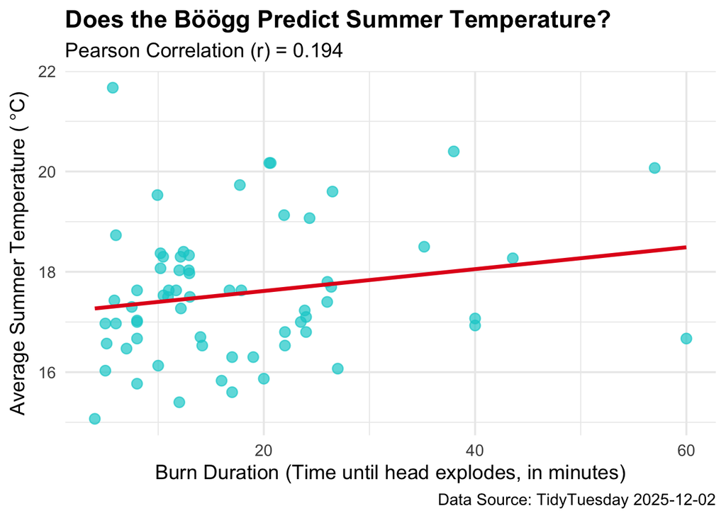

Relationship between Böögg Burn Duration and Average Summer Temperature (tre200m0)

```r
correlation_r <- cor( # Calculate the correlation coefficient (r)
  x = sechselaeuten$duration, # first variable
  y = sechselaeuten$tre200m0, #Second variable
  method = "pearson", #Type of correlation
  use = "pairwise.complete.obs") #Ignore missing values pair by pair

snowman_plot <- ggplot(sechselaeuten, aes(x = duration, y = tre200m0)) + #Making plot
  geom_point(color = "#00CED1", size = 3, alpha = 0.7) + #scatter points
  geom_smooth(method = "lm", color = "#e31a1c", se = FALSE) + #Add linear regression line
  labs( #Titles and labels
    title = "Does the Böögg Predict Summer Temperature?",
    subtitle = paste0("Pearson Correlation (r) = ", round(correlation_r, 3)),
    x = "Burn Duration (Time until head explodes, in minutes)",
    y = expression("Average Summer Temperature ("*~degree*C*")"), # Use expression for degree symbol
    caption = "Data Source: TidyTuesday 2025-12-02") +
  theme_minimal(base_size = 14) +
  theme(plot.title = element_text(face = "bold"))

print(snowman_plot)
```

```r
#Not saving the plot bc the quarto doc is the output for this homework not the plot
```